# Lab 5

Michael Egle

4/13/2020

```r
library(tidyverse)
library(lubridate)
accident <- read.csv("https://raw.githubusercontent.com/xdaiISU/ds202materials/master/hwlabs/fars2017/accident.csv", stringsAsFactors = FALSE)

person <- read.csv("https://raw.githubusercontent.com/xdaiISU/ds202materials/master/hwlabs/fars2017/person.csv", stringsAsFactors = FALSE)
```

1. Are there some days of the week where more accidents happen than on others (use variable `DAY_WEEK`)?

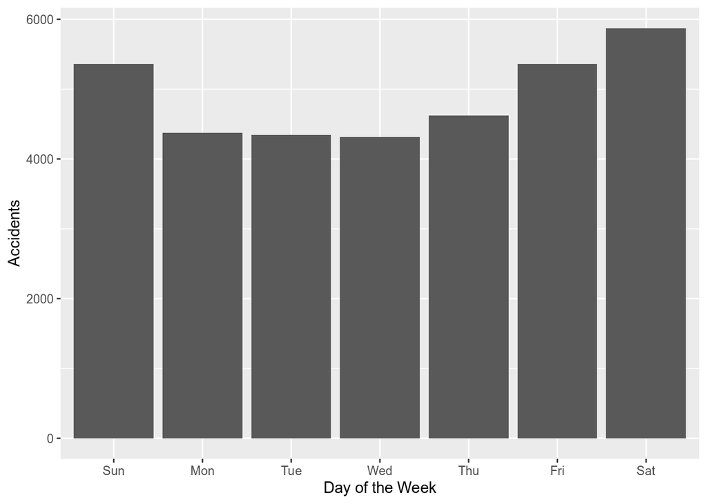

```r
  accident %>%
    ggplot(aes(x=wday(DAY_WEEK, label=TRUE))) + geom_bar() + xlab('Day of the Week') + ylab('Accidents')
```

2. What time of the day do accidents happen (use variable `HOUR`)?

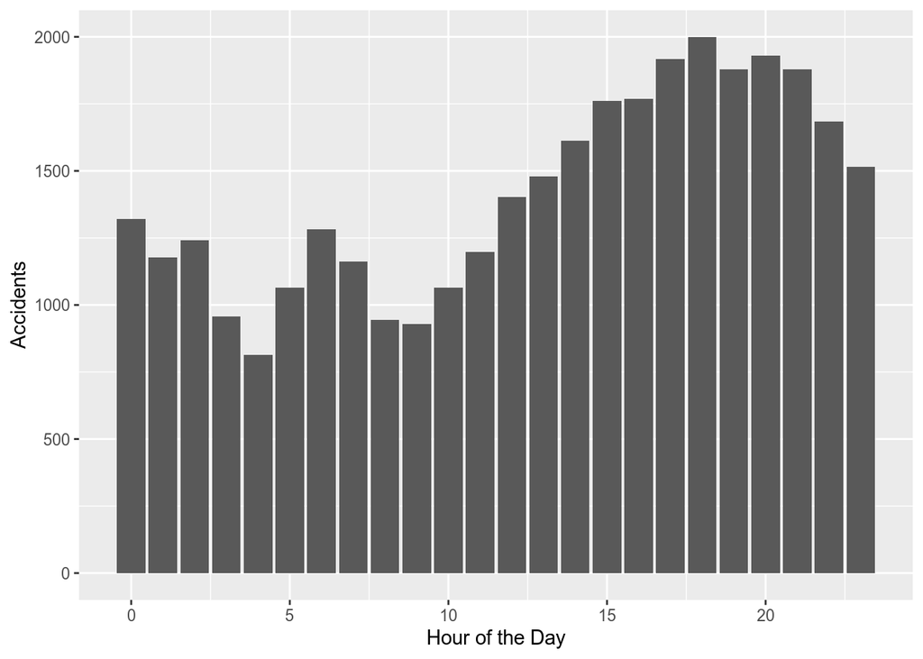

```r
  accident %>% filter(HOUR < 24) %>%
    ggplot(aes(x=HOUR)) + geom_bar() +
    xlab('Hour of the Day') + ylab('Accidents')
```

3. What is the number of accidents with at least one drunk driver (use variable `DRUNK_DR`)?

```r
  result <- accident %>% filter(DRUNK_DR >= 1) %>%
    summarize(n = n())

  result$n
```

```
## [1] 8769
```

There exist 8769 accidents in this data set with at least one drunk driver.

4. In the person table, identify drivers (PER_TYP == 1, see FARS manual) and subset on them.

```r
drivers <- person %>%
  filter(PER_TYP == 1)
```

5. Join accident and person table (work out which variable(s) to use)

```r
accident <- accident %>%
  inner_join(person)
```

6. Tally the number of accidents by day of the week (DAY_WEEK), hour of the day (HOUR) and gender (SEX). Visualize the results.

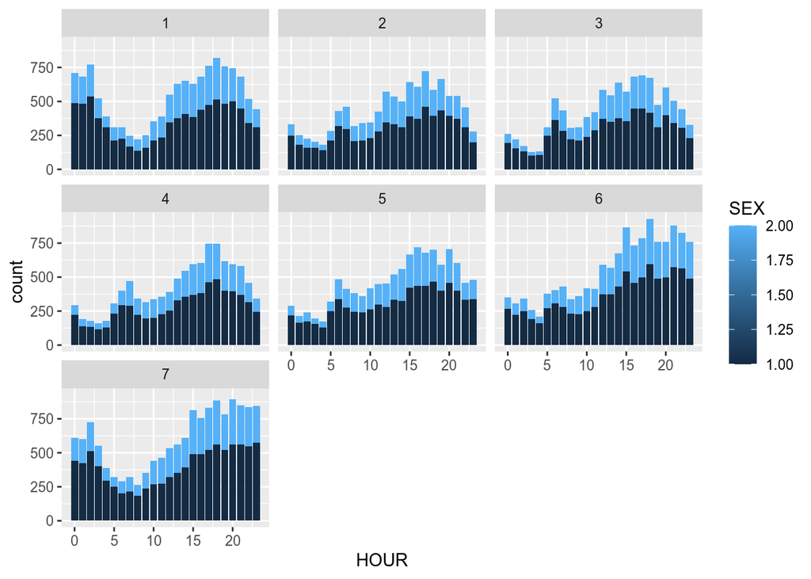

```r
accident %>%
  group_by(DAY_WEEK, HOUR, SEX) %>%
  filter(HOUR != 99, SEX == 1 | SEX == 2) %>%
  summarize(count = n()) %>%
  ggplot(aes(x = HOUR, y = count, fill = SEX)) +
  facet_wrap(. ~ DAY_WEEK) +
  geom_bar(stat = "identity")
```

7. Now plot a choropleth map of accidents on a county level

Read the description for the STATE and COUNTY columns in the FARS manual. The state & county codes are Geographic Locator Codes (GLCs) from the General Services Administration’s (GSA) publication. Use readxl::read_xlsx to read in the GLCs

```r
fars <- readxl::read_xlsx('GLC.xlsx')
fars <- fars %>%
  mutate_at(.vars = vars(`State Code`, `County Code`),
            .funs = funs(as.integer))
accident <- accident %>%
  inner_join(fars, by = c('STATE' = 'State Code', 'COUNTY' = 'County Code'))
```

8. Visualize the number of accidents in each county using a choropleth map. To do this, you need to join the accident data, GLCs, and appropriate map data.

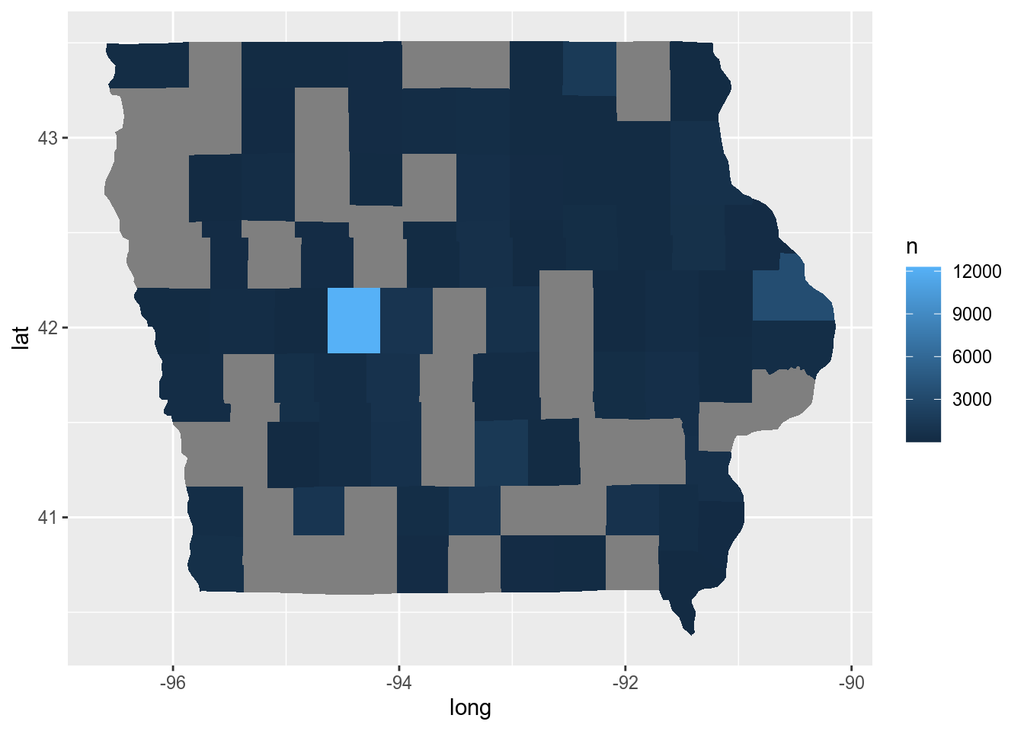

```r
fars_iowa <- fars %>%
  filter(`State Name` == 'IOWA') %>%
  distinct(`County Code`, `County Name`)

accident_iowa <- accident %>%
  filter(STATE == 1)

counties <- map_data('county') %>% filter(region == 'iowa')
total_accidents <- accident_iowa %>% group_by(COUNTY) %>% summarize(n = n())
counties$subregion <- str_to_upper(counties$subregion)

full_join(
  counties,
  inner_join(total_accidents, fars_iowa, by = c('COUNTY' = 'County Code')),
  by = c('subregion' = 'County Name')
) %>%
  ggplot(aes(x = long, y = lat)) + geom_polygon(aes(group = subregion, fill = n)) + labs(color = 'Accidents')
```

9. Can you find seasonal trends in accident occurrences in different states? Is summer or winter more dangerous? Why?

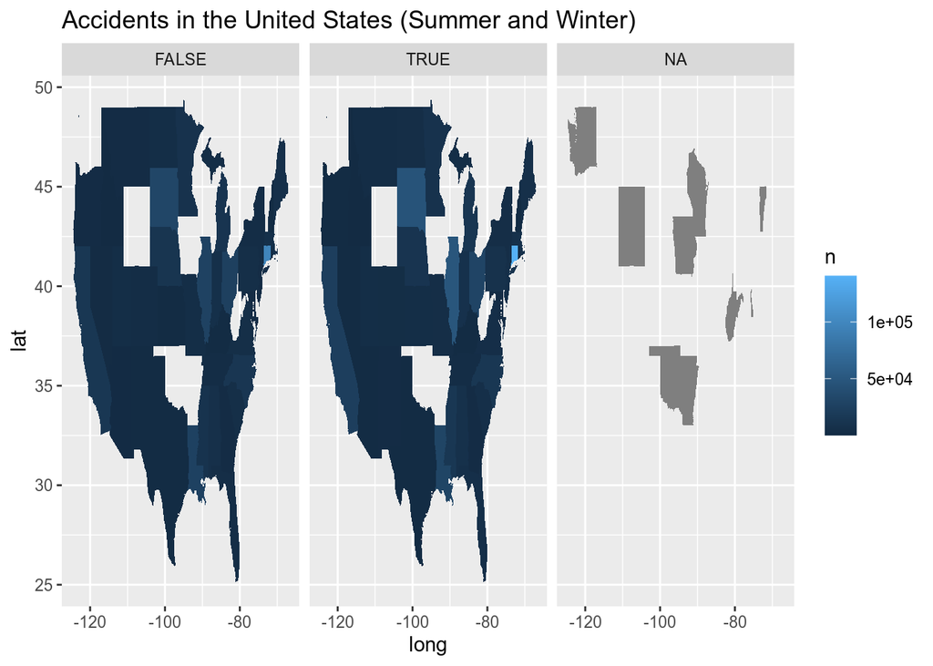

```r
states <- map_data('state')

winter <- accident %>%
  filter(MONTH == 12 | MONTH < 3) %>%
  group_by(STATE) %>%
  summarize(n = n())
winter$winter = TRUE

summer <- accident %>%
  filter(MONTH > 6 & MONTH < 9) %>%
  group_by(STATE) %>%
  summarize(n = n())
summer$winter = FALSE

full_join(states, full_join(summer, winter), by = c('group' = 'STATE')) %>%
  ggplot(aes(x = long, y = lat)) +
  geom_polygon(aes(group = group, fill = n)) +
  facet_grid(~ winter) +
  ggtitle('Accidents in the United States (Summer and Winter)')
```